# MSDS 6306 Final Project - Attrition & Salary Modeling

Bethel Kumsa

8/05/2020

# **Introduction & Dataset**

DDSAnalytics manages talent for fortune 500 companies. This analytics company is considering employing data science as a tool in servicing the company’s clients.

Through a dataset provided by DDSAnayltics, we model and predict attrition and monthly pay as means of introducing the company’s leadership to the talent management solutions that may be leveraged through data science.

Please watch the video presentation meant to accompany this analysis on [YouTube](https://www.youtube.com/watch?v=TVP0cFca9jM).

Note: The loading of libraries is hidden from this RMD for ease of reading.

# **Top 3 Factors Impacting Attrition**

#### Step 1: Clean Up/Modifications

We first load in our dataset. We then modify our nominal and ordinal variables and represnt their values as integers. Finally, we remove 3 columns, each of which contained one value for all data points.

```r
attData = read.csv("CaseStudy2-data.csv", header = TRUE)
attDataNumeric = attData

#Modify nominal and ordinal variables to be represented by integers.

attDataNumeric$Attrition = ifelse(attDataNumeric$Attrition == "No",0,1)

attDataNumeric$BusinessTravel = ifelse(attDataNumeric$BusinessTravel == "Non-Travel",0,
                                ifelse(attDataNumeric$BusinessTravel == "Travel_Rarely",1,2))

attDataNumeric$Department = ifelse(attDataNumeric$Department == "Human Resources",0,
                                   ifelse(attDataNumeric$Department == "Research & Development",1,2))

attDataNumeric$EducationField = ifelse(attDataNumeric$EducationField == "Other",0,
                                   ifelse(attDataNumeric$EducationField == "Human Resources",1,
                                          ifelse(attDataNumeric$EducationField == "Life Science",2,
                                                 ifelse(attDataNumeric$EducationField == "Marketing",3,
                                                        ifelse(attDataNumeric$EducationField == "Medical",4,5)))))

attDataNumeric$Gender = ifelse(attDataNumeric$Gender == "Male",0,1)

attDataNumeric$JobRole = ifelse(attDataNumeric$JobRole == "Healthcare Representative",0,
                                       ifelse(attDataNumeric$JobRole == "Human Resources",1,
                                              ifelse(attDataNumeric$JobRole == "Laboratory Technician",2,
                                                     ifelse(attDataNumeric$JobRole == "Manager",3,
                                                            ifelse(attDataNumeric$JobRole == "Manufacturing Director",4,
                                                                   ifelse(attDataNumeric$JobRole == "Research Director",5,
                                                                          ifelse(attDataNumeric$JobRole == "Research Scientist",6,
                                                                                 ifelse(attDataNumeric$JobRole == "Sales Executive",7,8))))))))

attDataNumeric$MaritalStatus = ifelse(attDataNumeric$MaritalStatus == "Single",0,
                                       ifelse(attDataNumeric$MaritalStatus == "Married",1,2))

attDataNumeric$OverTime = ifelse(attDataNumeric$OverTime == "No",0,1)

#Remove columns containing variables with only one value in preparation for logistic regression.
attDataNumeric = select(attDataNumeric, -c(EmployeeCount,Over18,StandardHours))
```

#### Step 2: Logistic Regression & ANOVA

**All Variables Containing 2 or More Values:** We fit a logistic regression model for attrition against the modified, cleaned dataset. We then review the p-values found in the model’s summary to determine which variables are statistically significant. We run ANOVA against this model and compare the residual deviance explained by each variable.

Note: The larger the deviance explained by the addition of a variable, the more impactful that variable is in determining attrition.

**Variables Determined as Statistical Significant Through First GLM:** Again, we fit a logistic regression model for attrition against only attrition and the explanatory variables determined as statistically significant in the previous model. Again, we run ANOVA against this model and compare the residual deviance explained by each variable.

**Variables Determined as Most Important Factors:** We fit a third logistic regression model for attrition against the top 6 contributors to attrition as determined by the first two models. Again, we run ANOVA against this model and compare the residual deviance explained by each variable.

**Top 3 Explanatory Variables Predicting Attrition:** We determine and graph, the conditional and general dominance of each of the 6 top explanatory variables predicting attrition using the dominanceanalysis library. In this way, we determine overtime, marital status, and total years working as the top 3 factors contributing to attrition.

**Correlation Heatmap:** We creating a correlation heatmap for each of the explanatory variables to further visualize the relationships between attrition and the explanatory variables as well as the relationships between the explanatory variables.

**Note:** Summaries of GLM outputs are commented out for an easier read.

```r
#First GLM
fitAttrition <- glm(Attrition~., data=attDataNumeric, family=binomial(link='logit'))
#summary(fitAttrition)
anovaAttrition = anova(fitAttrition, test="Chisq")

#Second GLM
fitAttritionSig <- glm(Attrition~BusinessTravel+Department+DistanceFromHome+EnvironmentSatisfaction+JobInvolvement+
                         JobSatisfaction+MaritalStatus+NumCompaniesWorked+OverTime+RelationshipSatisfaction+TotalWorkingYears+
                         TrainingTimesLastYear+WorkLifeBalance+YearsInCurrentRole+YearsSinceLastPromotion+YearsWithCurrManager,
                       data=attDataNumeric, family=binomial(link='logit'))
#summary(fitAttritionSig)
anovaAttritionSig = anova(fitAttritionSig, test="Chisq")

#Third GLM
fitAttritionTopFactors <- glm(Attrition~OverTime+JobInvolvement+MaritalStatus+TotalWorkingYears+YearsSinceLastPromotion+JobSatisfaction,
                       data=attDataNumeric, family=binomial(link='logit'))
#summary(fitAttritionTopFactors)
anovaAttritionTopFactors = anova(fitAttritionTopFactors, test="Chisq")

#Creating columns to store deviance explained by each variable.
anovaAttrition$devianceExplained[1] = 0
anovaAttritionSig$devianceExplained[1] = 0
anovaAttritionTopFactors$devianceExplained[1] = 0

#Determining deviance explained by each variable.
for(i in 2:length(anovaAttritionSig$`Resid. Dev`)-1)
{
  anovaAttritionSig$devianceExplained[i+1] = anovaAttritionSig$`Resid. Dev`[i] - anovaAttritionSig$`Resid. Dev`[i+1]
}


for(i in 2:length(anovaAttrition$`Resid. Dev`)-1)
{
  anovaAttrition$devianceExplained[i+1] = anovaAttrition$`Resid. Dev`[i] - anovaAttrition$`Resid. Dev`[i+1]
}


for(i in 2:length(anovaAttritionTopFactors$`Resid. Dev`)-1)
{
  anovaAttritionTopFactors$devianceExplained[i+1] = anovaAttritionTopFactors$`Resid. Dev`[i] - anovaAttritionTopFactors$`Resid. Dev`[i+1]
}

#Sorting by deviance explained - ascending.
anovaAttrition = anovaAttrition[order(-anovaAttrition$devianceExplained),]
anovaAttritionSig = anovaAttritionSig[order(-anovaAttritionSig$devianceExplained),]
anovaAttritionTopFactors = anovaAttritionTopFactors[order(-anovaAttritionTopFactors$devianceExplained),]

anovaAttrition
```

```
## Analysis of Deviance Table
##
## Model: binomial, link: logit
##
## Response: Attrition
##
## Terms added sequentially (first to last)
##
##
##                          Df Deviance Resid. Df Resid. Dev Pr(>Chi)
## OverTime                  1   59.411       848     556.76  0.00000
## JobInvolvement            1   30.186       856     687.92  0.00000
## MaritalStatus             1   25.396       852     629.13  0.00000
## Age                       1   19.971       867     745.76  0.00001
## JobLevel                  1   18.241       855     669.68  0.00002
## YearsSinceLastPromotion   1   18.131       838     502.88  0.00002
## JobSatisfaction           1   15.143       853     654.53  0.00010
## NumCompaniesWorked        1   12.324       849     616.17  0.00045
## WorkLifeBalance           1   10.088       841     529.09  0.00149
## YearsInCurrentRole        1    7.225       839     521.01  0.00719
## TrainingTimesLastYear     1    7.145       842     539.18  0.00752
## DistanceFromHome          1    6.794       863     726.08  0.00915
## Department                1    6.398       864     732.88  0.01143
## YearsWithCurrManager      1    6.059       837     496.82  0.01383
## BusinessTravel            1    5.892       866     739.86  0.01521
## EnvironmentSatisfaction   1    5.248       859     720.22  0.02198
## RelationshipSatisfaction  1    4.695       845     552.02  0.03024
## TotalWorkingYears         1    4.081       843     546.32  0.04336
## ID                        1    1.947       868     765.73  0.16296
## StockOptionLevel          1    1.623       844     550.40  0.20273
## HourlyRate                1    1.504       857     718.10  0.22005
## YearsAtCompany            1    0.852       840     528.24  0.35588
## Gender                    1    0.608       858     719.61  0.43543
## DailyRate                 1    0.591       865     739.27  0.44215
## MonthlyRate               1    0.379       850     628.49  0.53822
## Education                 1    0.313       862     725.77  0.57570
## MonthlyIncome             1    0.261       851     628.87  0.60963
## EmployeeNumber            1    0.239       860     725.46  0.62519
## EducationField            1    0.066       861     725.70  0.79719
## PercentSalaryHike         1    0.024       847     556.73  0.87718
```

[output cut: 22 more lines]

```
## ID                                   1.947
## StockOptionLevel                     1.623
## HourlyRate                           1.504
## YearsAtCompany                       0.852
## Gender                               0.608
## DailyRate                            0.591
## MonthlyRate                          0.379
## Education                            0.313
## MonthlyIncome                        0.261
## EmployeeNumber                       0.239
## EducationField                       0.066
## PercentSalaryHike                    0.024
## PerformanceRating                    0.013
## JobRole                              0.008
## NULL                                 0.000
```

```r
anovaAttritionSig
```

```
## Analysis of Deviance Table
##
## Model: binomial, link: logit
##
## Response: Attrition
##
## Terms added sequentially (first to last)
##
##
##                          Df Deviance Resid. Df Resid. Dev Pr(>Chi)
## OverTime                  1   61.242       860     603.79 0.000000
## TotalWorkingYears         1   39.285       858     560.72 0.000000
## MaritalStatus             1   31.797       862     668.81 0.000000
## JobInvolvement            1   29.409       864     714.84 0.000000
## YearsSinceLastPromotion   1   23.935       854     518.30 0.000001
## JobSatisfaction           1   14.238       863     700.61 0.000161
## WorkLifeBalance           1   10.261       856     544.33 0.001359
## DistanceFromHome          1    6.758       866     748.64 0.009332
## Department                1    6.658       867     755.40 0.009871
## TrainingTimesLastYear     1    6.133       857     554.59 0.013267
## BusinessTravel            1    5.619       868     762.05 0.017769
## EnvironmentSatisfaction   1    4.385       865     744.25 0.036259
## RelationshipSatisfaction  1    3.784       859     600.01 0.051743
## NumCompaniesWorked        1    3.774       861     665.03 0.052046
## YearsWithCurrManager      1    3.182       853     515.12 0.074442
## YearsInCurrentRole        1    2.091       855     542.24 0.148140
## NULL                                       869     767.67
##                          devianceExplained
## OverTime                            61.242
## TotalWorkingYears                   39.285
## MaritalStatus                       31.797
## JobInvolvement                      29.409
## YearsSinceLastPromotion             23.935
## JobSatisfaction                     14.238
## WorkLifeBalance                     10.261
## DistanceFromHome                     6.758
## Department                           6.658
## TrainingTimesLastYear                6.133
## BusinessTravel                       5.619
## EnvironmentSatisfaction              4.385
## RelationshipSatisfaction             3.784
## NumCompaniesWorked                   3.774
## YearsWithCurrManager                 3.182
## YearsInCurrentRole                   2.091
## NULL                                 0.000
```

```r
anovaAttritionTopFactors
```

```
## Analysis of Deviance Table
##
## Model: binomial, link: logit
##
## Response: Attrition
##
## Terms added sequentially (first to last)
##
##
##                         Df Deviance Resid. Df Resid. Dev  Pr(>Chi)
## OverTime                 1   58.870       868     708.80 0.0000000
## MaritalStatus            1   33.222       866     647.11 0.0000000
## JobInvolvement           1   28.473       867     680.33 0.0000001
## TotalWorkingYears        1   22.825       865     624.28 0.0000018
## JobSatisfaction          1   19.931       863     596.18 0.0000080
## YearsSinceLastPromotion  1    8.176       864     616.11 0.0042443
## NULL                                      869     767.67
##                         devianceExplained
## OverTime                           58.870
## MaritalStatus                      33.222
## JobInvolvement                     28.473
## TotalWorkingYears                  22.825
## JobSatisfaction                    19.931
## YearsSinceLastPromotion             8.176
## NULL                                0.000
```

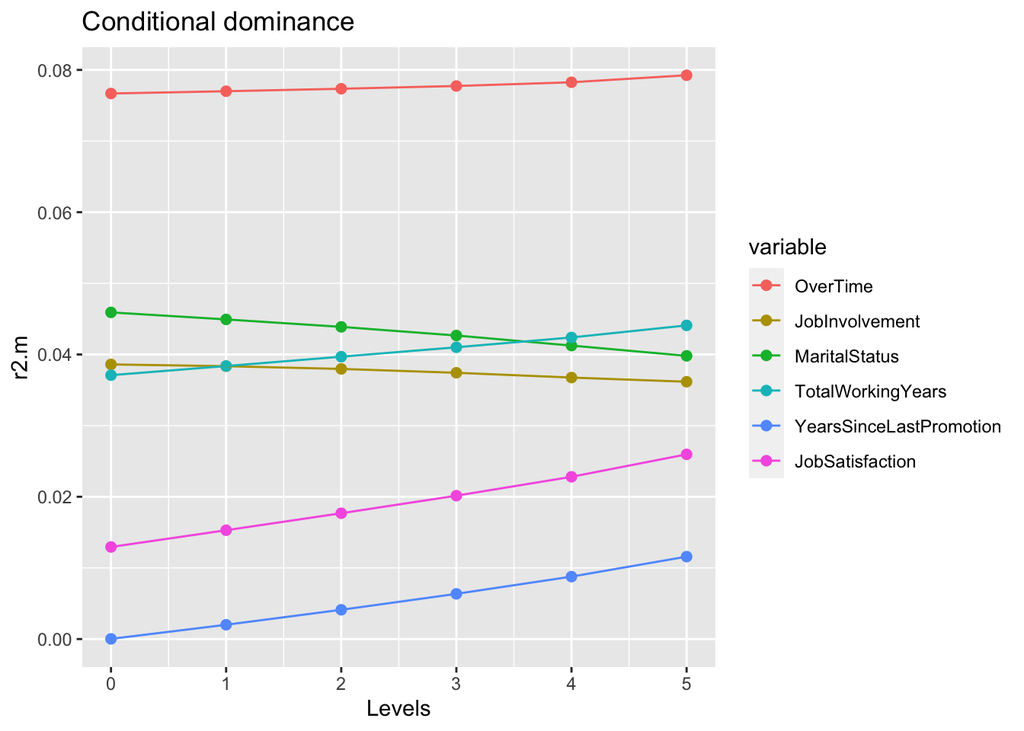

```r
domAnalysisAttrition<-dominanceAnalysis(fitAttritionTopFactors)
plot(domAnalysisAttrition, which.graph ="conditional",fit.function = "r2.m")
```

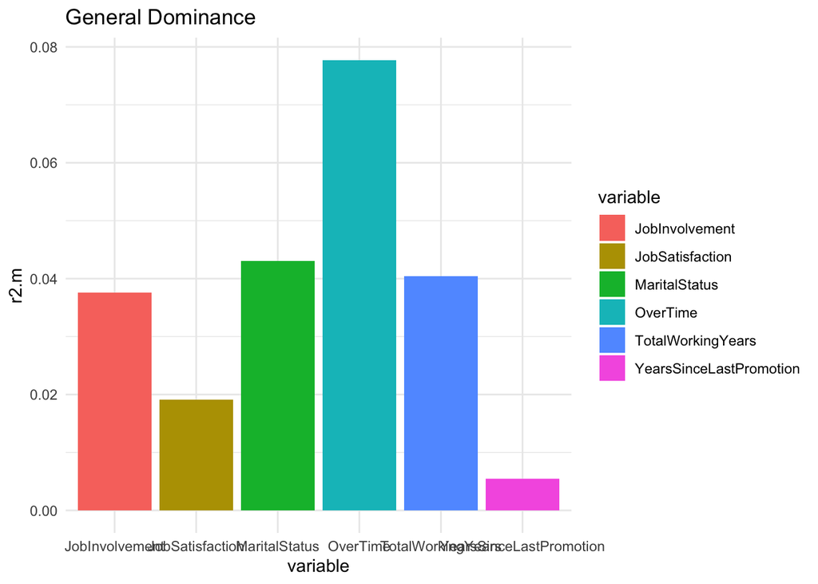

```r
plot(domAnalysisAttrition, which.graph ="general",fit.function = "r2.m")
```

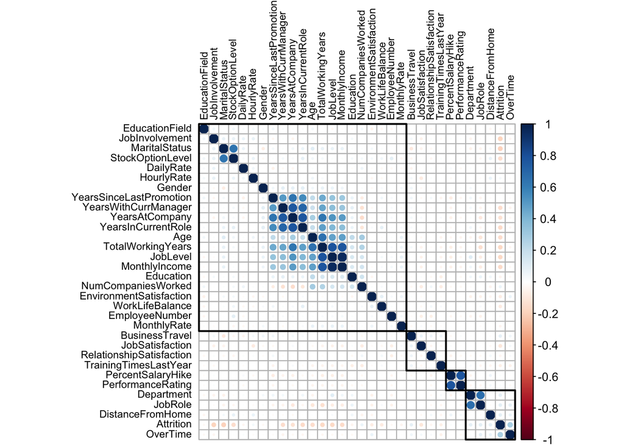

```r
#Correlation Heatmap
corrHeatMap = cor(attDataNumeric[c(2:33)], method = "pearson")
corrplot(corrHeatMap, tl.col = "black", order = "hclust", hclust.method = "average", addrect = 4, tl.cex = 0.7)
```

# **Classification Models for Attrition**

#### The k-NN Model Achieved the lowest specificities, reaching as low as 0%

#### The basic tree (C5.0) model achived a wide range of specificities typically between 30% and 85%.

#### The logistic regression model achieved the highest speficities typically between 60% and 85%

**Note:** Summaries of classifications outputs are commented out for an easier read.

```r
splitPerc = 0.7

# Knn Model for Attrition Classification

trainAttritionIndicies = sample(1:dim(attData)[1],round(splitPerc * dim(attData)[1]))

trainAttritionKnn = na.omit(attDataNumeric[trainAttritionIndicies,])
testAttritionKnn = na.omit(attDataNumeric[-trainAttritionIndicies,])
confusionMatrix(table(knn(trainAttritionKnn[,c(18,22,27)],testAttritionKnn[,c(18,22,27)],trainAttritionKnn[,3], k=3),testAttritionKnn[,3]))
```

```
## Confusion Matrix and Statistics
##
##
##       0   1
##   0 204  33
##   1  14  10
##
##                Accuracy : 0.8199
##                  95% CI : (0.7678, 0.8646)
##     No Information Rate : 0.8352
##     P-Value [Acc > NIR] : 0.77609
##
##                   Kappa : 0.2046
##
##  Mcnemar's Test P-Value : 0.00865
##
##             Sensitivity : 0.9358
##             Specificity : 0.2326
##          Pos Pred Value : 0.8608
##          Neg Pred Value : 0.4167
##              Prevalence : 0.8352
##          Detection Rate : 0.7816
##    Detection Prevalence : 0.9080
##       Balanced Accuracy : 0.5842
##
##        'Positive' Class : 0
##
```

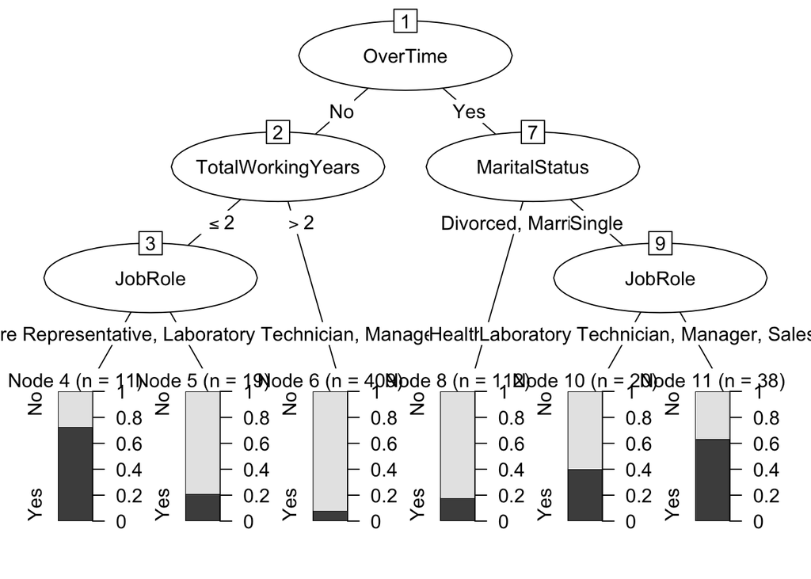

```r
# Logistic Regression Model and Basic Tree Model Test and Train Sets

trainAttritionGLM = na.omit(attData[trainAttritionIndicies,])
trainAttritionGLM = select(trainAttritionGLM,Attrition,OverTime,JobInvolvement,MaritalStatus,TotalWorkingYears,BusinessTravel,JobRole)
trainAttritionTree = trainAttritionGLM
trainAttritionGLM$Attrition = ifelse(trainAttritionGLM$Attrition == "No",0,1)

testAttritionGLM = na.omit(attData[-trainAttritionIndicies,])
testAttritionGLM = select(testAttritionGLM,Attrition,OverTime,JobInvolvement,MaritalStatus,TotalWorkingYears,BusinessTravel,JobRole)
testAttritionTree = testAttritionGLM
testAttritionGLM$Attrition = ifelse(testAttritionGLM$Attrition == "No",0,1)


#Basic Tree Model

treeModel = C5.0(x = trainAttritionTree[2:7], y = trainAttritionTree$Attrition)
#summary(treeModel)
plot(treeModel)
```

```r
predAttritionTree = predict(treeModel, newdata = testAttritionTree[2:7])
confusionMatrix(table(testAttritionTree$Attrition,predAttritionTree))
```

```
## Confusion Matrix and Statistics
##
##      predAttritionTree
##        No Yes
##   No  204  14
##   Yes  33  10
##
##                Accuracy : 0.8199
##                  95% CI : (0.7678, 0.8646)
##     No Information Rate : 0.908
##     P-Value [Acc > NIR] : 1.00000
##
##                   Kappa : 0.2046
##
##  Mcnemar's Test P-Value : 0.00865
##
##             Sensitivity : 0.8608
##             Specificity : 0.4167
##          Pos Pred Value : 0.9358
##          Neg Pred Value : 0.2326
##              Prevalence : 0.9080
##          Detection Rate : 0.7816
##    Detection Prevalence : 0.8352
##       Balanced Accuracy : 0.6387
##
##        'Positive' Class : No
##
```

```r
#Logistic Regression Model

modelAttritionLog <- glm(formula = Attrition~., family=binomial(link='logit'), data=trainAttritionGLM)
#summary(modelAttritionLog)
predAttrition <- predict(modelAttritionLog,testAttritionGLM, type = 'response')
predAttrition <- ifelse(predAttrition>0.5,1,0)
modelAttritionAccuracy = 1-(mean(predAttrition != testAttritionGLM$Attrition))
confusionMatrix(table(testAttritionGLM$Attrition,predAttrition))
```

```
## Confusion Matrix and Statistics
##
##    predAttrition
##       0   1
##   0 212   6
##   1  29  14
##
##                Accuracy : 0.8659
##                  95% CI : (0.8185, 0.9048)
##     No Information Rate : 0.9234
##     P-Value [Acc > NIR] : 0.9995320
##
##                   Kappa : 0.3795
##
##  Mcnemar's Test P-Value : 0.0002003
##
##             Sensitivity : 0.8797
##             Specificity : 0.7000
##          Pos Pred Value : 0.9725
##          Neg Pred Value : 0.3256
##              Prevalence : 0.9234
##          Detection Rate : 0.8123
##    Detection Prevalence : 0.8352
##       Balanced Accuracy : 0.7898
##
##        'Positive' Class : 0
##
```

# **Predictive Model for Monthly Income**

**Clean Data:** We create a new dataframe including only **numeric** explanatory variables.

**Standardize Data:** We use scale to standardize data.

**Determine Most Impactful Explanatory Variables:** We fit a linear regression model against monthly income for the dataset of unscaled and scaled data. The **standardized/scaled** data allows us to compare the coefficients rendered by the linear regression model to determine which explanatory variables are most impactful in predicting monthly income. We determine job level, total working years, percent salary hike, and job involvement as the most predictive explanatory variables for monthly income and use these variables in our final linear regression prediction model.

**RMSE:** Typically ranged between 1,300 dollars and 1,600 dollars.

```r
splitPerc = 0.7

# Model for Salary Prediction

#Remove columns containing non-numeric variables with only one value in preparation for logistic regression.
salaryDataNumeric = attData[c(2,5,7,8,12,14,15,16,18,20,21,22,25:27,29:36)]

#Standardize the data.
salaryDataNumericScaled= as.data.frame(scale(salaryDataNumeric))

fitUnsacaled = lm(MonthlyIncome~., data = salaryDataNumeric)
fitScaled = lm(MonthlyIncome~., data = salaryDataNumericScaled)

#summary(fitScaled)
#summary(fitUnsacaled)

#Use the scaled, ordered coefficients derived from the lm output to determine the most impactful factors in predicting monthly income.
scaledCoefficients = fitScaled$coefficients
scaledCoefficients = data.frame(ScaledVariable = names(scaledCoefficients), CoefficientValues = unname(scaledCoefficients))
scaledCoefficients = scaledCoefficients[order(-scaledCoefficients$CoefficientValues),]

#Trainig and test sets for linear regression model.
trainSalaryIndicies = sample(1:dim(attData)[1],round(splitPerc * dim(attData)[1]))
trainSalary = attData[trainSalaryIndicies,]
testSalary = attData[-trainSalaryIndicies,]

#Linear regression model to predict monthly income based on most impactful factors.
fitSalary = lm(MonthlyIncome~JobLevel+TotalWorkingYears+PercentSalaryHike+JobInvolvement, data = trainSalary)
summary(fitSalary)
```

```
##
## Call:
## lm(formula = MonthlyIncome ~ JobLevel + TotalWorkingYears + PercentSalaryHike +
##     JobInvolvement, data = trainSalary)
##
## Residuals:
##     Min      1Q  Median      3Q     Max
## -4590.0  -957.0    73.0   753.3  3898.2
##
## Coefficients:
##                    Estimate Std. Error t value Pr(>|t|)
## (Intercept)       -2216.912    338.769  -6.544 1.28e-10 ***
## JobLevel           3695.219     80.105  46.130  < 2e-16 ***
## TotalWorkingYears    61.514     11.642   5.284 1.77e-07 ***
## PercentSalaryHike     2.678     14.818   0.181   0.8566
## JobInvolvement      138.158     78.998   1.749   0.0808 .
## ---
## Signif. codes:  0 '***' 0.001 '**' 0.01 '*' 0.05 '.' 0.1 ' ' 1
##
## Residual standard error: 1363 on 604 degrees of freedom
## Multiple R-squared:  0.9127, Adjusted R-squared:  0.9121
## F-statistic:  1578 on 4 and 604 DF,  p-value: < 2.2e-16
```

```r
#confint(fitSalary)

predictedSalary = predict(fitSalary, newdata = testSalary)

#Cross-Validation
MSPE = data.frame(Observed = testSalary$MonthlyIncome, Predicted = predictedSalary)
MSPE$Resisdual = MSPE$Observed - MSPE$Predicted
MSPE$SquaredResidual = MSPE$Resisdual^2
mean(MSPE$SquaredResidual)
```

```
## [1] 2104954
```

# **Models Against Provided Incomplete Datasets**

```r
#Attrition

incompleteAttID = read.csv("CaseStudy2CompSet_No Attrition.csv", header = TRUE)
incompleteAtt = select(incompleteAttID,OverTime,JobInvolvement,MaritalStatus,Department,BusinessTravel,JobRole)
trainAttritionGLMFinaL = na.omit(attData)
trainAttritionGLMFinaL = select(trainAttritionGLMFinaL,Attrition,OverTime,JobInvolvement,MaritalStatus,Department,BusinessTravel,JobRole)
trainAttritionGLMFinaL$Attrition = ifelse(trainAttritionGLMFinaL$Attrition == "No",0,1)

modelAttritionGLMFinal <- glm(formula = Attrition~., family=binomial(link='logit'), data=trainAttritionGLMFinaL)
#summary(modelAttritionGLMFinal)
predAttritionFinal = predict(modelAttritionGLMFinal,incompleteAtt, type = 'response')
predAttritionFinal = ifelse(predAttritionFinal>0.5,1,0)
predAttritionFinal = ifelse(predAttritionFinal == 0,"No","Yes")
predAttritionFinalDF = data.frame(ID = incompleteAttID$ID, Attrition = unname(predAttritionFinal))
write.csv(predAttritionFinalDF,'Case2PredictionsKumsa Attrition.csv',row.names=FALSE)

#Monthly Income

incompleteSalary = read.csv("CaseStudy2CompSet_No Salary.csv", header = TRUE)
trainSalaryFinal = na.omit(attData)

#Linear regression model to predict monthly income based on most impactful factors.
fitSalaryFinal = lm(MonthlyIncome~JobLevel+TotalWorkingYears+PercentSalaryHike+JobInvolvement, data = trainSalaryFinal)
#summary(fitSalaryFinal)

predictedSalaryFinal = predict(fitSalaryFinal, newdata = incompleteSalary)
predSalaryFinalDF = data.frame(ID = incompleteSalary$ID, MonthlyIncome = predictedSalaryFinal)
write.csv(predSalaryFinalDF,'Case2PredictionsKumsa Salary.csv',row.names=FALSE)
```

# **Job Role Specific Trends & Other Insights**

**Job Role Specific Trends:** Healthcare representatives maintain longes careers at DDS Analytics with a majority of their working years spent at this company. Very few human resources personnel remain at the company after the 10th year mark. DDSAnalytics typically hires research directors with about 20 years of experience.

**Other Insights:** For a majority of job roles, there is a higher rate of attrition for those working overtime than amongst those not working overtime.

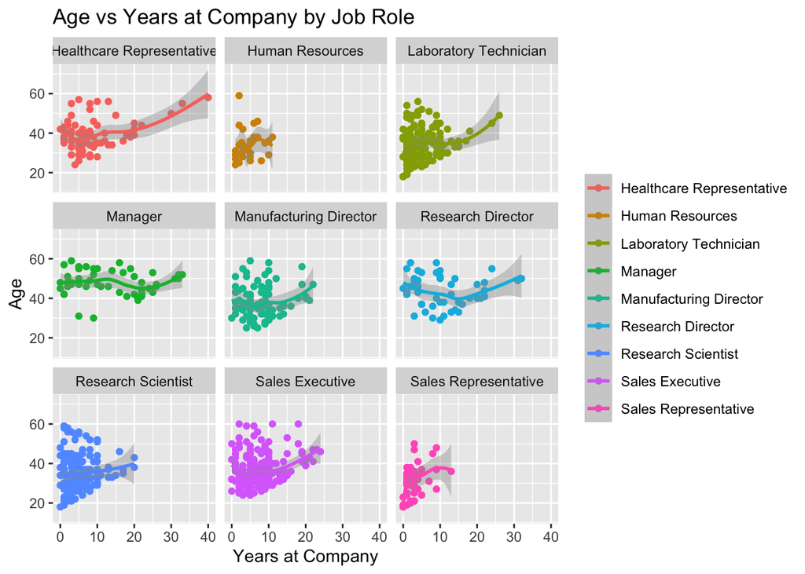

```r
ggplot(data = attData, mapping = aes(x=YearsAtCompany, y = Age, color = JobRole)) +
  geom_point() +
  geom_smooth() +
  facet_wrap(~JobRole) +
  theme(legend.title=element_blank()) +
  ggtitle("Age vs Years at Company by Job Role") +
  xlab("Years at Company") + ylab("Age")
```

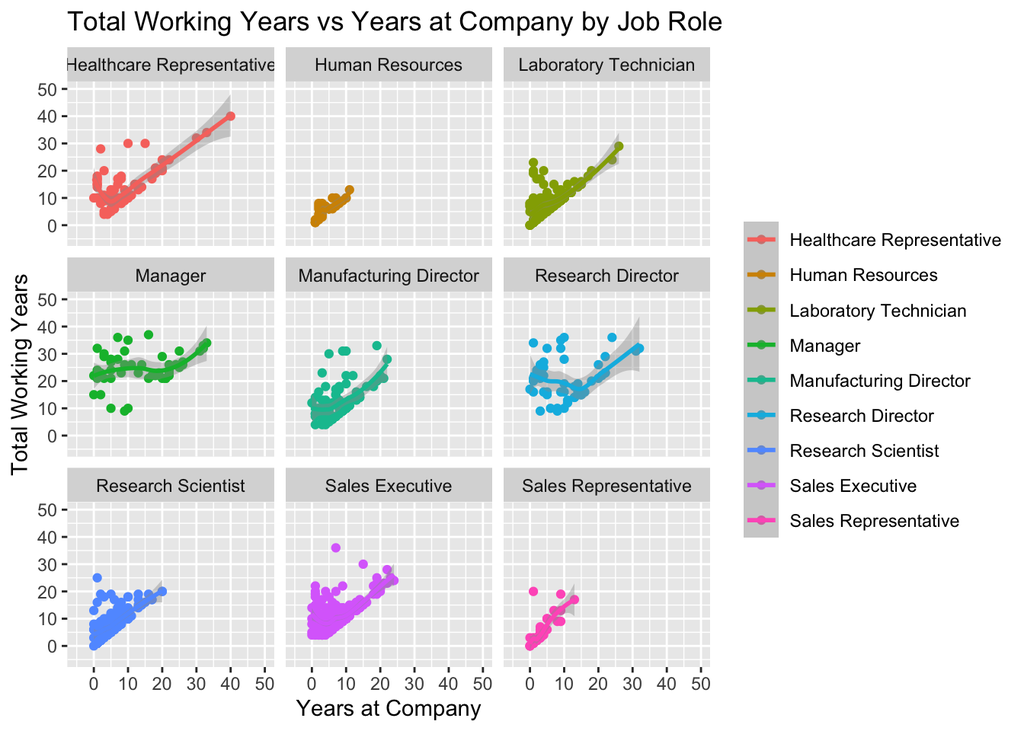

```r
ggplot(data = attData, mapping = aes(x=YearsAtCompany, y = TotalWorkingYears, color = JobRole)) +
  geom_point() +
  geom_smooth() +
  facet_wrap(~JobRole) +
  theme(legend.title=element_blank()) +
  ggtitle("Total Working Years vs Years at Company by Job Role") +
  xlab("Years at Company") + ylab("Total Working Years") +
  xlim(-5, 50) + ylim(-5,50)
```

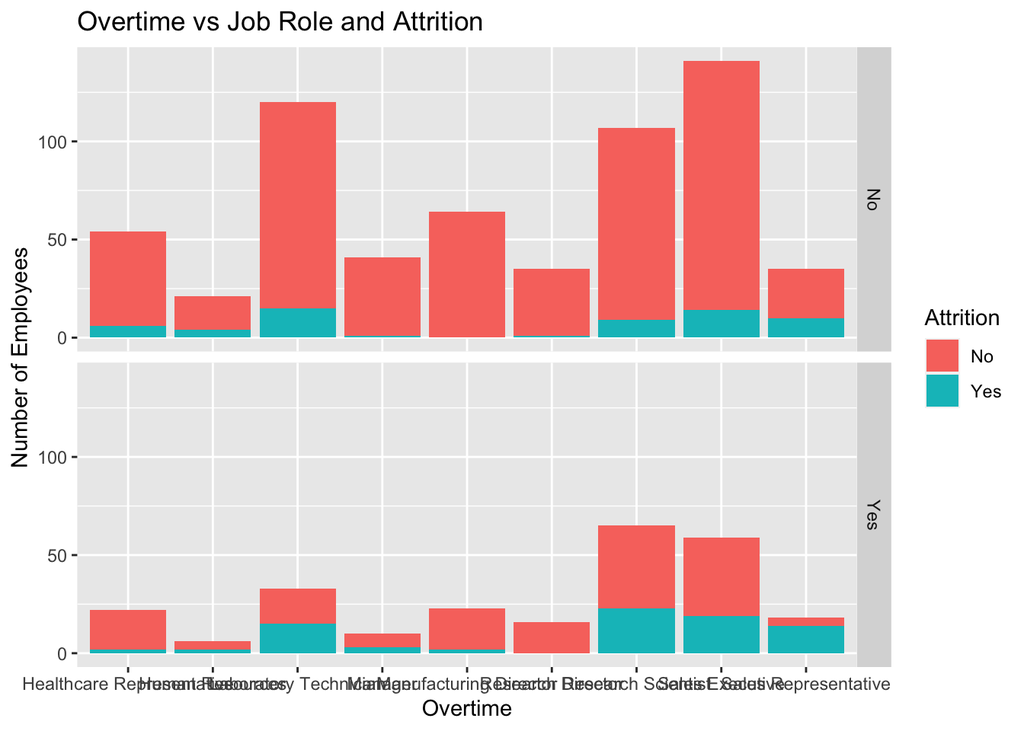

```r
attData2 <- attData %>%
  group_by(JobRole,OverTime,Attrition) %>%
  summarise(count=n()) %>%
  mutate(perc=count/sum(count))

ggplot(data = attData, mapping = aes(x= JobRole, fill = Attrition)) +
  geom_bar() +
  facet_grid(OverTime~.) +
  ggtitle("Overtime vs Job Role and Attrition") +
  xlab("Overtime") + ylab("Number of Employees")
```

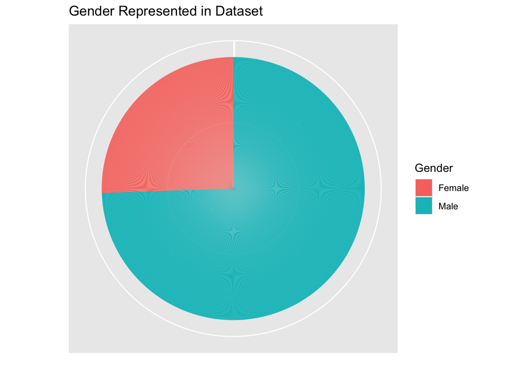

```r
ggplot(data = attData, mapping = aes(x= "", y= Gender, fill = Gender)) +
  geom_bar(width = 1, stat = "identity") + coord_polar("y", start=0) +
  theme(axis.text.x = element_blank(), axis.ticks = element_blank()) +
  xlab("") + ylab("") + ggtitle("Gender Represented in Dataset")
```

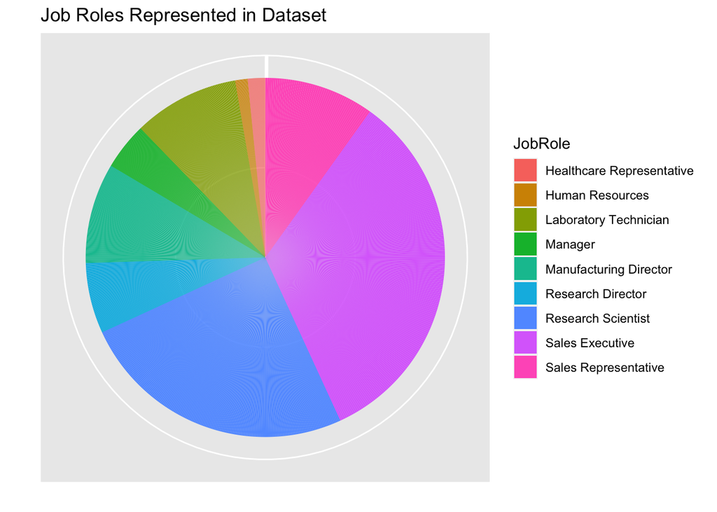

```r
ggplot(data = attData, mapping = aes(x= "", y= JobRole, fill = JobRole)) +
  geom_bar(width = 1, stat = "identity") + coord_polar("y", start=0) +
  theme(axis.text.x = element_blank(), axis.ticks = element_blank()) +
  xlab("") + ylab("") + ggtitle("Job Roles Represented in Dataset")
```